# Project for Practical Machine Learning Course

Raj Ayala

January 24, 2015

#### This is the course project for the Applied Machine Learning course.

#### In this project, data from a Human Activity Learning experiment is used. The data was collected from accelerometers on the belt, forearm, arm, and dumbell of 6 participants. They were asked to perform barbell lifts correctly and incorrectly in 5 different ways. More information is available from the website here: http://groupware.les.inf.puc-rio.br/har (see the section on the Weight Lifting Exercise Dataset).

#### The goal of the project is to predict the manner in which they did the exercise. This is the “classe” variable in the training set.

#### Here, we describe how we built your model, how cross validation is used, what the expected out of sample error is, and why we made the choices you did. We then apply the prediction model to predict 20 different test cases.

### DATA PREPARATION

#### Read data, eliminate NA columns and other unneeded columns

```r
library(AppliedPredictiveModeling)
library(caret)
library(rattle)
```

```r
library(rpart)
library(rpart.plot)
library(randomForest)
library(MASS)
library(klaR)

## setwd("./Documents/datasciencecoursera")
training <- read.csv("./data/pml-training.csv", stringsAsFactors = FALSE, na.strings = c("#DIV/0!", "NA", ""))
testing <- read.csv("./data/pml-testing.csv", stringsAsFactors = FALSE, na.strings = c("#DIV/0!", "NA", ""))

## Delete all rows where "new_window" is "yes" as this appears to be summary data with some invalid values

training <- subset(training,  new_window != "yes")

## Remove all columns with "all NA" values from both training and test data frames
## If the count of NAs in a column is equal to the number of rows, it must be entirely NA.

training <- training[,colSums(is.na(training)) != nrow(training)]

## Remove first seven columns as they are not needed for prediction

training <- training[, 8:ncol(training)]
training$classe <- as.factor(training$classe)

## Retain only identical columns in testing set, as in the training set, except for the last column, whose name is different

namestrain <- colnames(training)
namestrain <- namestrain[-length(namestrain)]   ## remove the last name, which is outcome "classe"

testing <- testing[, c(namestrain, "problem_id")]

# Verify that the column names (excluding classe and problem_id) are identical in the training and test set.

namestest <- colnames(testing)
namestest <- namestest[-length(namestest)]   ## remove the last name, which is outcome "problem_id"

all.equal(namestrain, namestest)
```

```
## [1] TRUE
```

#### At this point, we have reduced the data from 160 variables to 53 variables, one of them being the output variable, and hence we have 52 covariates. Let’s see if any of these coavariates have “near zero variance.”

```r
nzv <- nearZeroVar(training, saveMetrics=TRUE)
nzv
```

```
##                      freqRatio percentUnique zeroVar   nzv
## roll_belt             1.086168    6.83805162   FALSE FALSE
## pitch_belt            1.036649    9.53892590   FALSE FALSE
## yaw_belt              1.047244   10.10616153   FALSE FALSE
## total_accel_belt      1.069434    0.15091590   FALSE FALSE
## gyros_belt_x          1.050784    0.72335554   FALSE FALSE
## gyros_belt_y          1.148947    0.35907577   FALSE FALSE
## gyros_belt_z          1.071098    0.87947544   FALSE FALSE
## accel_belt_x          1.059367    0.85345545   FALSE FALSE
## accel_belt_y          1.115333    0.74417152   FALSE FALSE
## accel_belt_z          1.080702    1.55599500   FALSE FALSE
## magnet_belt_x         1.089080    1.70170691   FALSE FALSE
## magnet_belt_y         1.096519    1.55079101   FALSE FALSE
## magnet_belt_z         1.019481    2.37302248   FALSE FALSE
## roll_arm             51.153846   13.75936719   FALSE FALSE
## pitch_arm            85.282051   15.96065779   FALSE FALSE
## yaw_arm              32.281553   14.89904246   FALSE FALSE
## total_accel_arm       1.020316    0.34346378   FALSE FALSE
## gyros_arm_x           1.023715    3.34616986   FALSE FALSE
## gyros_arm_y           1.450593    1.95149875   FALSE FALSE
## gyros_arm_z           1.118908    1.29059117   FALSE FALSE
## accel_arm_x           1.017751    4.04350541   FALSE FALSE
## accel_arm_y           1.169082    2.78413822   FALSE FALSE
## accel_arm_z           1.139344    4.12156536   FALSE FALSE
## magnet_arm_x          1.011765    6.96294754   FALSE FALSE
## magnet_arm_y          1.045455    4.53268110   FALSE FALSE
## magnet_arm_z          1.027778    6.57785179   FALSE FALSE
## roll_dumbbell         1.037879   84.17464613   FALSE FALSE
## pitch_dumbbell        2.248175   81.73397169   FALSE FALSE
## yaw_dumbbell          1.132231   83.34721066   FALSE FALSE
## total_accel_dumbbell  1.081020    0.22377186   FALSE FALSE
## gyros_dumbbell_x      1.010050    1.25416320   FALSE FALSE
## gyros_dumbbell_y      1.270979    1.44150708   FALSE FALSE
## gyros_dumbbell_z      1.052632    1.06681932   FALSE FALSE
## accel_dumbbell_x      1.006061    2.21169858   FALSE FALSE
## accel_dumbbell_y      1.062500    2.41985845   FALSE FALSE
## accel_dumbbell_z      1.150215    2.12323064   FALSE FALSE
## magnet_dumbbell_x     1.093567    5.84929226   FALSE FALSE
## magnet_dumbbell_y     1.188571    4.38176520   FALSE FALSE
## magnet_dumbbell_z     1.026596    3.51269775   FALSE FALSE
## roll_forearm         11.726154   11.23542881   FALSE FALSE
## pitch_forearm        64.576271   15.09679434   FALSE FALSE
## yaw_forearm          15.236000   10.29870941   FALSE FALSE
## total_accel_forearm   1.132729    0.36427977   FALSE FALSE
## gyros_forearm_x       1.050193    1.54558701   FALSE FALSE
## gyros_forearm_y       1.043011    3.84054954   FALSE FALSE
## gyros_forearm_z       1.112051    1.58201499   FALSE FALSE
## accel_forearm_x       1.142857    4.13197336   FALSE FALSE
## accel_forearm_y       1.050000    5.20920067   FALSE FALSE
## accel_forearm_z       1.019231    3.01311407   FALSE FALSE
## magnet_forearm_x      1.012658    7.92568693   FALSE FALSE
## magnet_forearm_y      1.256410    9.72626978   FALSE FALSE
## magnet_forearm_z      1.017544    8.75832639   FALSE FALSE
## classe                1.471490    0.02601998   FALSE FALSE
```

#### We see that nzv is false for all of the covariants. So, we can’t eliminate any covariants at this point.

### DATA PARTITIONING FOR MODEL BUILDING

#### Try different statistical models and see how good they are

#### First, split traing into subsets of training and test

```r
## Split traing data into 2 subsets to help build right model and experimenting and testing with different models

## First, partition training data into 2 blocks
set.seed(1234)
index <- createDataPartition(y=training$classe, p=0.5, list=FALSE)
block1 <- training[index,]
block2 <- training[-index,]

## Divide each of the 2 data blocks into training and test sets (60% to 40% ratio)
set.seed(1234)
inTrain <- createDataPartition(y=block1$classe, p=0.6, list=FALSE)
train1 <- block1[inTrain,]
test1 <- block1[-inTrain,]
set.seed(1234)
inTrain <- createDataPartition(y=block2$classe, p=0.6, list=FALSE)
train2 <-block2[inTrain,]
test2 <- block2[-inTrain,]
```

### 1. Classification Tree Model

```r
## Classification Tree
## Run against training set 1
set.seed(1234)
modFit <- train(train1$classe ~ ., data = train1, method="rpart")
print(modFit, digits=3)
```

```
## CART
##
## 5768 samples
##   52 predictor
##    5 classes: 'A', 'B', 'C', 'D', 'E'
##
## No pre-processing
## Resampling: Bootstrapped (25 reps)
##
## Summary of sample sizes: 5768, 5768, 5768, 5768, 5768, 5768, ...
##
## Resampling results across tuning parameters:
##
##   cp      Accuracy  Kappa   Accuracy SD  Kappa SD
##   0.0378  0.499     0.3456  0.0436       0.0699
##   0.0622  0.423     0.2235  0.0697       0.1114
##   0.1185  0.314     0.0489  0.0399       0.0612
##
## Accuracy was used to select the optimal model using  the largest value.
## The final value used for the model was cp = 0.0378.
```

```r
print(modFit$finalModel, digits=3)
```

```
## n= 5768
##
## node), split, n, loss, yval, (yprob)
##       * denotes terminal node
##
##  1) root 5768 4130 A (0.28 0.19 0.17 0.16 0.18)
##    2) roll_belt< 130 5247 3620 A (0.31 0.21 0.19 0.18 0.11)
##      4) pitch_forearm< -33.9 476    3 A (0.99 0.0063 0 0 0) *
##      5) pitch_forearm>=-33.9 4771 3620 A (0.24 0.23 0.21 0.2 0.12)
##       10) magnet_dumbbell_y< 440 3999 2870 A (0.28 0.18 0.24 0.19 0.1)
##         20) roll_forearm< 124 2495 1480 A (0.41 0.19 0.18 0.17 0.058) *
##         21) roll_forearm>=124 1504  988 C (0.074 0.17 0.34 0.24 0.17) *
##       11) magnet_dumbbell_y>=440 772  382 B (0.032 0.51 0.044 0.23 0.19) *
##    3) roll_belt>=130 521   16 E (0.031 0 0 0 0.97) *
```

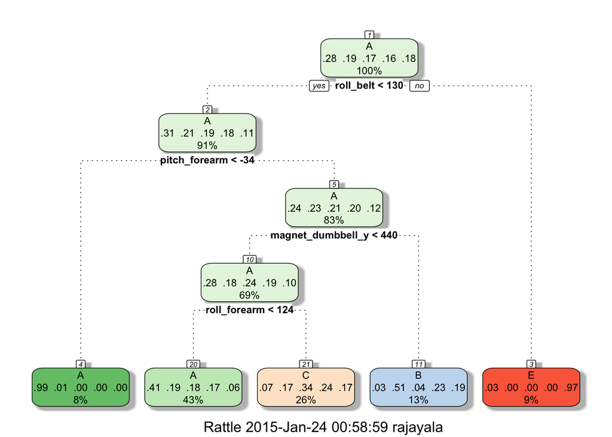

```r
fancyRpartPlot(modFit$finalModel)
```

```r
## Run against test set 1 with same features as in training set

pred <- predict(modFit, newdata=test1)
print(confusionMatrix(pred, test1$classe), digits=4)
```

```
## Confusion Matrix and Statistics
##
##           Reference
## Prediction   A   B   C   D   E
##          A 975 306 321 289  94
##          B   9 260  20 106  84
##          C  96 177 329 234 180
##          D   0   0   0   0   0
##          E  14   0   0   0 347
##
## Overall Statistics
##
##                Accuracy : 0.4975
##                  95% CI : (0.4816, 0.5135)
##     No Information Rate : 0.2848
##     P-Value [Acc > NIR] : < 2.2e-16
##
##                   Kappa : 0.3434
##  Mcnemar's Test P-Value : NA
##
## Statistics by Class:
##
##                      Class: A Class: B Class: C Class: D Class: E
## Sensitivity            0.8912  0.34993  0.49104   0.0000  0.49220
## Specificity            0.6323  0.92931  0.78335   1.0000  0.99554
## Pos Pred Value         0.4912  0.54280  0.32382      NaN  0.96122
## Neg Pred Value         0.9359  0.85634  0.87929   0.8362  0.89713
## Prevalence             0.2848  0.19344  0.17443   0.1638  0.18355
## Detection Rate         0.2538  0.06769  0.08565   0.0000  0.09034
## Detection Prevalence   0.5168  0.12471  0.26451   0.0000  0.09399
## Balanced Accuracy      0.7618  0.63962  0.63720   0.5000  0.74387
```

### As the accuracy is quite low (49.75%), let’s try preprocessing and cross validation of training data

```r
## Run with preprocessing only
set.seed(1234)
modFit <- train(train1$classe ~., preProcess=c("center", "scale"), data=train1, method="rpart")
print(modFit, digits=3)
```

```
## CART
##
## 5768 samples
##   52 predictor
##    5 classes: 'A', 'B', 'C', 'D', 'E'
##
## Pre-processing: centered, scaled
## Resampling: Bootstrapped (25 reps)
##
## Summary of sample sizes: 5768, 5768, 5768, 5768, 5768, 5768, ...
##
## Resampling results across tuning parameters:
##
##   cp      Accuracy  Kappa   Accuracy SD  Kappa SD
##   0.0378  0.499     0.3456  0.0436       0.0699
##   0.0622  0.423     0.2235  0.0697       0.1114
##   0.1185  0.314     0.0489  0.0399       0.0612
##
## Accuracy was used to select the optimal model using  the largest value.
## The final value used for the model was cp = 0.0378.
```

#### Pre-processing did not change the accuracy of prediction. So, let’s try cross-validation now.

```r
## Run with cross-validation only
set.seed(1234)
modFit <- train(train1$classe ~., trControl=trainControl(method = "cv", number = 4), data=train1, method="rpart")
print(modFit, digits=3)
```

```
## CART
##
## 5768 samples
##   52 predictor
##    5 classes: 'A', 'B', 'C', 'D', 'E'
##
## No pre-processing
## Resampling: Cross-Validated (4 fold)
##
## Summary of sample sizes: 4325, 4326, 4325, 4328
##
## Resampling results across tuning parameters:
##
##   cp      Accuracy  Kappa   Accuracy SD  Kappa SD
##   0.0378  0.518     0.3701  0.0294       0.0394
##   0.0622  0.400     0.1815  0.0680       0.1131
##   0.1185  0.324     0.0597  0.0451       0.0691
##
## Accuracy was used to select the optimal model using  the largest value.
## The final value used for the model was cp = 0.0378.
```

#### Cross-validation increased the accuracy just a little bit to 51.8%. Now, let’s try doing both pre-processing and cross validation, with classification tree.

```r
## Run preprocessing and cross validation on train1 data
set.seed(1234)
modFit <- train(train1$classe ~., preProcess=c("center", "scale"), trControl=trainControl(method = "cv", number = 4), data=train1, method="rpart")
print(modFit, digits=3)
```

```
## CART
##
## 5768 samples
##   52 predictor
##    5 classes: 'A', 'B', 'C', 'D', 'E'
##
## Pre-processing: centered, scaled
## Resampling: Cross-Validated (4 fold)
##
## Summary of sample sizes: 4325, 4326, 4325, 4328
##
## Resampling results across tuning parameters:
##
##   cp      Accuracy  Kappa   Accuracy SD  Kappa SD
##   0.0378  0.518     0.3701  0.0294       0.0394
##   0.0622  0.400     0.1815  0.0680       0.1131
##   0.1185  0.324     0.0597  0.0451       0.0691
##
## Accuracy was used to select the optimal model using  the largest value.
## The final value used for the model was cp = 0.0378.
```

```r
## Run against test1 data with preprocessing and cross validation
pred <- predict(modFit, newdata=test1)
print(confusionMatrix(pred, test1$classe), digits=4)
```

```
## Confusion Matrix and Statistics
##
##           Reference
## Prediction   A   B   C   D   E
##          A 975 307 321 289  94
##          B   9 260  20 106  84
##          C  96 176 329 234 180
##          D   0   0   0   0   0
##          E  14   0   0   0 347
##
## Overall Statistics
##
##                Accuracy : 0.4975
##                  95% CI : (0.4816, 0.5135)
##     No Information Rate : 0.2848
##     P-Value [Acc > NIR] : < 2.2e-16
##
##                   Kappa : 0.3434
##  Mcnemar's Test P-Value : NA
##
## Statistics by Class:
##
##                      Class: A Class: B Class: C Class: D Class: E
## Sensitivity            0.8912  0.34993  0.49104   0.0000  0.49220
## Specificity            0.6320  0.92931  0.78366   1.0000  0.99554
## Pos Pred Value         0.4909  0.54280  0.32414      NaN  0.96122
## Neg Pred Value         0.9358  0.85634  0.87933   0.8362  0.89713
## Prevalence             0.2848  0.19344  0.17443   0.1638  0.18355
## Detection Rate         0.2538  0.06769  0.08565   0.0000  0.09034
## Detection Prevalence   0.5171  0.12471  0.26425   0.0000  0.09399
## Balanced Accuracy      0.7616  0.63962  0.63735   0.5000  0.74387
```

### 2. Random Forest Model

```r
## Preprocess and cross validate train1 data.
set.seed(1234)
modFit <- train(train1$classe ~ ., method="rf", preProcess=c("center", "scale"), trControl=trainControl(method = "cv", number = 4), data=train1)
print(modFit, digits=3)
```

```
## Random Forest
##
## 5768 samples
##   52 predictor
##    5 classes: 'A', 'B', 'C', 'D', 'E'
##
## Pre-processing: centered, scaled
## Resampling: Cross-Validated (4 fold)
##
## Summary of sample sizes: 4325, 4326, 4325, 4328
##
## Resampling results across tuning parameters:
##
##   mtry  Accuracy  Kappa  Accuracy SD  Kappa SD
##    2    0.971     0.964  0.00344      0.00436
##   27    0.972     0.965  0.00713      0.00902
##   52    0.966     0.957  0.00590      0.00746
##
## Accuracy was used to select the optimal model using  the largest value.
## The final value used for the model was mtry = 27.
```

```r
## Run model against test1 data.
pred <- predict(modFit, newdata=test1)
print(confusionMatrix(pred, test1$classe), digits=4)
```

```
## Confusion Matrix and Statistics
##
##           Reference
## Prediction    A    B    C    D    E
##          A 1088   16    0    0    2
##          B    1  712   15    1    2
##          C    2   15  646   11    1
##          D    2    0    9  616    5
##          E    1    0    0    1  695
##
## Overall Statistics
##
##                Accuracy : 0.9781
##                  95% CI : (0.973, 0.9825)
##     No Information Rate : 0.2848
##     P-Value [Acc > NIR] : < 2.2e-16
##
##                   Kappa : 0.9723
##  Mcnemar's Test P-Value : 0.006525
##
## Statistics by Class:
##
##                      Class: A Class: B Class: C Class: D Class: E
## Sensitivity            0.9945   0.9583   0.9642   0.9793   0.9858
## Specificity            0.9934   0.9939   0.9909   0.9950   0.9994
## Pos Pred Value         0.9837   0.9740   0.9570   0.9747   0.9971
## Neg Pred Value         0.9978   0.9900   0.9924   0.9959   0.9968
## Prevalence             0.2848   0.1934   0.1744   0.1638   0.1835
## Detection Rate         0.2833   0.1854   0.1682   0.1604   0.1809
## Detection Prevalence   0.2879   0.1903   0.1757   0.1645   0.1815
## Balanced Accuracy      0.9940   0.9761   0.9775   0.9872   0.9926
```

```r
## Preprocess and cross validate train2 data.
set.seed(1234)
modFit <- train(train2$classe ~ ., method="rf", preProcess=c("center", "scale"), trControl=trainControl(method = "cv", number = 4), data=train2)
print(modFit, digits=3)
```

```
## Random Forest
##
## 5766 samples
##   52 predictor
##    5 classes: 'A', 'B', 'C', 'D', 'E'
##
## Pre-processing: centered, scaled
## Resampling: Cross-Validated (4 fold)
##
## Summary of sample sizes: 4323, 4326, 4324, 4325
##
## Resampling results across tuning parameters:
##
##   mtry  Accuracy  Kappa  Accuracy SD  Kappa SD
##    2    0.975     0.969  0.00479      0.00607
##   27    0.978     0.972  0.00350      0.00444
##   52    0.968     0.960  0.00603      0.00764
##
## Accuracy was used to select the optimal model using  the largest value.
## The final value used for the model was mtry = 27.
```

```r
## Run model against test2 data.
pred <- predict(modFit, newdata=test2)
print(confusionMatrix(pred, test2$classe), digits=4)
```

```
## Confusion Matrix and Statistics
##
##           Reference
## Prediction    A    B    C    D    E
##          A 1085   23    0    0    0
##          B    5  709    7    0    2
##          C    3   10  663   19    2
##          D    0    1    0  609    3
##          E    1    0    0    1  698
##
## Overall Statistics
##
##                Accuracy : 0.98
##                  95% CI : (0.975, 0.9841)
##     No Information Rate : 0.2848
##     P-Value [Acc > NIR] : < 2.2e-16
##
##                   Kappa : 0.9746
##  Mcnemar's Test P-Value : NA
##
## Statistics by Class:
##
##                      Class: A Class: B Class: C Class: D Class: E
## Sensitivity            0.9918   0.9542   0.9896   0.9682   0.9901
## Specificity            0.9916   0.9955   0.9893   0.9988   0.9994
## Pos Pred Value         0.9792   0.9806   0.9512   0.9935   0.9971
## Neg Pred Value         0.9967   0.9891   0.9978   0.9938   0.9978
## Prevalence             0.2848   0.1934   0.1744   0.1638   0.1835
## Detection Rate         0.2825   0.1846   0.1726   0.1586   0.1817
## Detection Prevalence   0.2885   0.1882   0.1815   0.1596   0.1822
## Balanced Accuracy      0.9917   0.9749   0.9894   0.9835   0.9947
```

#### Accuracy is vastly improved with Random Forest along with pre-processing and cross validation

#### The accuracy for the two partitioned tset sets was 97.81% and 98% respectively.

#### Now, run the model to predict the outcomes in the test set given for the project

```r
# Run against 20 testing set given.
print(predict(modFit, testing))
```

```
##  [1] B A B A A E D B A A B C B A E E A B B B
## Levels: A B C D E
```

#### At this point, let’s examine whether any any parametric model-based predictions yield good results.

### 3. LINEAR DISCRIMINANT ANALYSIS

```r
## Linear Discriminant Analysis assumes that the probability function for class k (fk(x)) is Gaussian with same covariance

set.seed(1234)
modlda <- train(train1$classe ~ ., method="lda", data=train1)
print(modlda, digits=3)
```

```
## Linear Discriminant Analysis
##
## 5768 samples
##   52 predictor
##    5 classes: 'A', 'B', 'C', 'D', 'E'
##
## No pre-processing
## Resampling: Bootstrapped (25 reps)
##
## Summary of sample sizes: 5768, 5768, 5768, 5768, 5768, 5768, ...
##
## Resampling results
##
##   Accuracy  Kappa  Accuracy SD  Kappa SD
##   0.695     0.615  0.0116       0.0144
##
##
```

#### Now, let’s try LDA with precossing and cross-validation, and compare the results with pre-processed and cross-validated Classification Tree model.

```r
## Linear Discriminant Analysis (LDA) with preprocessing and cross-validation of train1 data.
set.seed(1234)
modlda <- train(train1$classe ~ ., method="lda", preProcess=c("center", "scale"), trControl=trainControl(method = "cv", number = 4), data=train1)
print(modlda, digits=3)
```

```
## Linear Discriminant Analysis
##
## 5768 samples
##   52 predictor
##    5 classes: 'A', 'B', 'C', 'D', 'E'
##
## Pre-processing: centered, scaled
## Resampling: Cross-Validated (4 fold)
##
## Summary of sample sizes: 4325, 4326, 4325, 4328
##
## Resampling results
##
##   Accuracy  Kappa  Accuracy SD  Kappa SD
##   0.702     0.623  0.0179       0.0225
##
##
```

#### LDA with preprocessing and cross-validation has increased the prediction accuracy to 70.2%

#### As the scoring for the project is based on accuracy of predictions, we will go with the Random Forest model

#### Out of Sample Error for the chosen Random Forest Model

#### The error rate after running the predict() function on the 2 testing sets, created from training subsets are:

##### - Random Forest (preprocessing and cross validation) Testing Set 1: 1 - .9781 = 0.0219

##### - Random Forest (preprocessing and cross validation) Testing Set 2: 1 - .98 = 0.02

### Since each testing set is roughly of equal size, we can average the out of sample error rates derived by applying the random forest method with both preprocessing and cross validation against test sets 1 & 2, yielding a predicted out of sample rate of 0.02095.

### CONCLUSION

#### Human Activity Recognition is an emerging technology which has wide variety of applications from medical to driver safety. This project uses the data fromUgulino, W.; Cardador, D.; Vega, K.; Velloso, E.; Milidiu, R.; Fuks, H. Wearable Computing: Accelerometers’ Data Classification of Body Postures and Movements, to classify the activity based on accelerometers on the belt, forearm, arm, and dumbell of a set of test participants.

#### The approach taken is to create further data partitions from the trainng data, building different models, using the models to predict the outcome variable (classe), estimating the accuracy of predictions, and then choosing the model which has highest accuracy to predict against the 20 cases given in th etesting data.

#### The models considered were Classification Tree, Linear Discriminant Analysis, and Random Forest. Data pre-processing and cross validation were applied to improve the acuuracy. The estimated accuracy for Classification Tree was about 50%, and it was about 70% for LDA, and 98% for Random Forest model.

#### The Random Forest model was applied to the testing data of 20 cases and all 20 cases were predicted accurately.